# TCGA RNASeq Counts EDA—KIRC

Ariel Balter

12 January, 2022

# 1 TCGA RNASeq Counts EDA—KIRC

## 1.1 DataSources

### 1.1.1 PanCan Atlas

https://gdc.cancer.gov/about-data/publications/pancanatlas

### 1.1.2 GDC—Workflow and Normalization

GDC gives very explicit details about their pipelines, including the actual code.

- RNASeq: https://docs.gdc.cancer.gov/Data/Bioinformatics_Pipelines/Expression_mRNA_Pipeline/
- MAF: https://docs.gdc.cancer.gov/Data/File_Formats/MAF_Format/

More information and data types, sources, and processing is in the [Data Dictionary](https://docs.gdc.cancer.gov/Data_Dictionary/viewer/).

It’s clear from the description and flowchart that the GDC pipeline does not do any normalization other than within sample FPKM and upper quantile normalized FPKM. Details are given the the pages linked to above. These are the values in the RNASeq file mentioned above. Still, as shown below, the across-sample data has a fairly consistent range. This suggests either incredible attention to detail in every step from processing samples to sequencing, or something else that I have not found documented yet.

The [GDC Data Portal](https://portal.gdc.cancer.gov/) is another source for data. The link they have for a description of the data links to the data dictionary described above.

### 1.1.3 TCGA

[This GDC page](https://gdc.cancer.gov/about-data/publications/PanCan-Clinical-2018) on the TCGA Pan-Cancer project links to some additional resources

### 1.1.4 ISB-CGC

[ISB-CGC](https://isb-cancer-genomics-cloud.readthedocs.io/en/latest/sections/PanCancer-Atlas-Mirror.html) hosts the raw data from GDC and other project in multiple formats, including BigQuery tables. This is actually where I am drawing data for this analysis.

I communicated with ISB-CGC.

> We have an exhaustive ETL process that does that huge manifest / download from the GDC portal. We’ve also got the Pancancer Atlas data in BQ format in our isb-cgc-bq.pancancer_atlas dataset

### 1.1.5 Choose a TCGA Project ID to Start With

```
tcga_cancer_name = "KIRC"
```

```r
tcga_cancer_name = "KIRC"
```

## 1.2 Collect Data

### 1.2.1 Set up BigQuery connection

```r
bq_auth(email = "ariel.balter@providence.org")
isb_conn = dbConnect(
  bigquery(),
  project="eacri-cancer-graph"
)
```

### 1.2.2 Mutations

This comes straight from the ISB-CGC maintained tables of the TCGA data.

Selecting the project KIRC.

**NOTE:** We are only interested in the barcodes for tumor samples

```r
proj_short_name = glue("TCGA-KIRC")

if(load_from_bq)
{
  mutations =

    tbl(isb_conn, "isb-cgc-bq.TCGA.somatic_mutation_hg38_gdc_current") %>%

    ### Just keep selected project
    filter(project_short_name == proj_short_name) %>%
    # filter(project_short_name %like% project_short_name) %>%
    # filter(project_short_name == project_short_name)

    ### Ignore most columns for now
    select(
      gene_symbol = Hugo_Symbol,
      variant_classification = Variant_Classification,
      sample_barcode = sample_barcode_tumor,
      sift = SIFT,
      poly_phen = PolyPhen,
      # vep = VEP
      impact = IMPACT
    ) %>%

    ### Download the table
    collect()

  write.fst(mutations, path="large_files/KIRC-mutations.fst", compress=T)

  object.size(mutations) %>% print(units = "MB", standard = "SI")
} else

{
  mutations = read.fst(path="large_files/KIRC-mutations.fst")
}
```

```
2.2 MB
```

### 1.2.3 RNASeq Expression Counts

We created our own BigQuery tables from the ISB-CGC RNASeq table split into TCGA Study/Project groups to make downloading the data feasible. Otherwise we query the ISB-CGC table and filter by cancer time which results in a longer and more expensive query.

Selected project: KIRC

```r
if (load_from_bq)
{
  table_name = paste0("eacri-cancer-graph.ISB_TCGA.", tcga_cancer_name)

  print(glue("Table Name: {table_name}"))

  rnaseq_counts =
    tbl(isb_conn, table_name) %>%

    select(
      gene_symbol = gene_name,
      sample_barcode,
      HTSeq__Counts,
      HTSeq__FPKM,
      HTSeq__FPKM_UQ
    ) %>%


    # filter(gene_symbol %in% random_genes) %>%

    ### The RNASeq table has counts for many samples besides the tumor
    ### samples for which we have mutation data. We only want to include
    ### the samples for which we have mutation data. We are interested in
    ### changes in expression in wildtype samples (for a given gene).
    ### However, a sample not being in the mutation table may not
    ### necessarily mean that it is wildtype in all genes. It could
    ### simply mean that TCGA did not include variant calls for that
    ### sample in the mutation table.
    ###
    ###         IS THIS TRUE????          ####
    ###         ----------------          ####
    # filter(sample_barcode %in% tumor_barcodes) %>%
    collect()

  write.fst(rnaseq_counts, path="large_files/KIRC-rnaseq_counts.fst", compress=100)

} else

{
  rnaseq_counts = read.fst(path="large_files/KIRC-rnaseq_counts.fst")
}
```

```
Table Name: eacri-cancer-graph.ISB_TCGA.KIRC
```

```r
# vroom_write(counts_and_mutations, file="large_files/KIRC-rnaseq.tsv")
# counts_and_mutations = vroom("large_files/KIRC-rnaseq.tsv")

# saveRDS(counts_and_mutations, file="large_files/KIRC-rnaseq.rds")
# counts_and_mutations = readRDS("large_files/KIRC-rnaseq.rds")
```

```r
tibble(rnaseq_counts = colnames(rnaseq_counts)) %>%
  displayTable(caption = "Columns in Counts Table")
```

| rnaseq_counts |
| --- |
| gene_symbol |
| sample_barcode |
| HTSeq__Counts |
| HTSeq__FPKM |
| HTSeq__FPKM_UQ |

```r
rnaseq_counts %>%
  head() %>%
  collect() %>%
  displayTable(caption = "Sample of Data")
```

| gene_symbol | sample_barcode | HTSeq__Counts | HTSeq__FPKM | HTSeq__FPKM_UQ |
| --- | --- | --- | --- | --- |
| RN7SL493P | TCGA-BP-4762-01A | 0 | 0 | 0 |
| pRNA | TCGA-CJ-4634-01A | 0 | 0 | 0 |
| RN7SL578P | TCGA-CW-6087-01A | 0 | 0 | 0 |
| RN7SL698P | TCGA-B0-5402-01A | 0 | 0 | 0 |
| RN7SKP22 | TCGA-B8-5545-01A | 0 | 0 | 0 |
| RN7SL219P | TCGA-B0-5119-01A | 0 | 0 | 0 |

```r
object.size(rnaseq_counts) %>% print(units = "MB", standard = "SI")
```

```
1334 MB
```

### 1.2.4 Combined table

For downstream analysis we join the MAF and RNASeq tables on the gene symobls and sample barcodes.

**Question:** Were the sample/gene pairs in the MAF table processed the same way as the ones not in the MAF table?

**Question:** Do we presume sample/gene pairs not in the MAF table do not have mutations? That would seem odd, since these are all tumor samples.

**NOTE:** we are adding a variable `gene_mutation_type` that captures whether that sample is or is not included in the MAF file. That is, were somatic mutations called for that sample.

#### 1.2.4.1 Samples in MAF vs RNASeq Tables

```r
mutation_barcodes =
  mutations %>%
  pull(sample_barcode) %>%
  unique()

rnaseq_barcodes =
  rnaseq_counts %>%
  pull(sample_barcode) %>%
  unique()

tibble(
  "Samples in MAF File" = length(mutation_barcodes),
  "Samples in RNASeq File" = length(rnaseq_barcodes),
  "Samples in Both" = intersect(mutation_barcodes, rnaseq_barcodes) %>% length()
) %>%
displayTable()
```

| Samples in MAF File | Samples in RNASeq File | Samples in Both |
| --- | --- | --- |
| 336 | 607 | 332 |

#### 1.2.4.2 Genes in MAF vs RNASeq Tables

```r
mutation_genes =
  mutations %>%
  pull(gene_symbol) %>%
  unique()

rnaseq_genes =
  rnaseq_counts %>%
  pull(gene_symbol) %>%
  unique()

tibble(
  "Genes in MAF File" = length(mutation_genes),
  "Genes in RNASeq File" = length(rnaseq_genes),
  "Genes in Both" = intersect(mutation_genes, rnaseq_genes) %>% length()
) %>%
displayTable()
```

| Genes in MAF File | Genes in RNASeq File | Genes in Both |
| --- | --- | --- |
| 12637 | 58387 | 12593 |

#### 1.2.4.3 Join the Tables

```r
if (load_from_bq)
{
  counts_and_mutations =

    ### Left join to keep all genes with rnaseq counts, even if they
    ### don't show up in the MAF table.
    full_join(

      rnaseq_counts %>%
        mutate(in_rnaseq_table = T),

      ### Add column to remember source of gene-sample pair
      mutations %>%
        mutate(in_maf_table = T),

      by = c("gene_symbol", "sample_barcode"),

      suffix = c(".maf", ".rnaseq")

    ) %>%

    mutate(
      ### Because we perform a left join into the rnaseq table,
      ### sample/gene pairs not in the MAF table will be NA.
      ### change to Not In MAF Table
      in_maf_table = ifelse(is.na(in_maf_table), F, T),
      in_rnaseq_table = ifelse(is.na(in_rnaseq_table), F, T),
      maf_only = ifelse(in_maf_table & !in_rnaseq_table, T, F),
      rnaseq_only = ifelse(in_rnaseq_table & !in_maf_table, T, F),
      gene_mutation_type = ifelse(in_maf_table, "Mutant", "Wildtype"),
      variant_classification = ifelse(is.na(variant_classification), "Wildtype", variant_classification)
    ) %>%

    filter(sample_barcode %in% mutation_barcodes)

  write.fst(counts_and_mutations, path="large_files/KIRC-counts_and_mutations.fst", compress=100)
} else
{
  counts_and_mutations = read.fst(path="large_files/KIRC-counts_and_mutations.fst")
}


## Delete tables no longer needed to save memory
# rm(mutations)
# rm(rnaseq_counts)
gc()
```

```
            used   (Mb) gc trigger    (Mb)   max used    (Mb)
Ncells   2665855  142.4    8194295   437.7   35720684  1907.7
Vcells 706290531 5388.6 1435776328 10954.2 1760424125 13431.0
```

## 1.3 Summary Stats

### 1.3.1 Mutations

```r
feature_count_summary =
  mutations %>%
  summarize(
    Num_Genes = n_distinct(gene_symbol),
    Num_Samples = n_distinct(sample_barcode),
    Num_Pairs = n_distinct(paste0(gene_symbol, sample_barcode))
  )

feature_count_summary %>% displayTable()
```

| Num_Genes | Num_Samples | Num_Pairs |
| --- | --- | --- |
| 12637 | 336 | 27938 |

### 1.3.2 Counts and Mutations—Various Summaries

```r
counts_and_mutations %>%
  summarize(
    N_Samples = n_distinct(sample_barcode),
    N_Genes = n_distinct(gene_symbol),
    N_Pairs = n_distinct(paste0(gene_symbol, sample_barcode))
  )
```

| N_Samples | N_Genes | N_Pairs |
| --- | --- | --- |
| 336 | 58431 | 19384948 |

```r
tibble(
  "Samples in MAF File" = length(mutation_barcodes),
  "Samples in RNASeq File" = length(rnaseq_barcodes),
  "Samples in Both" = intersect(mutation_barcodes, rnaseq_barcodes) %>% length()
) %>%
displayTable(caption = " Samples in MAF vs RNASeq Tables")
```

| Samples in MAF File | Samples in RNASeq File | Samples in Both |
| --- | --- | --- |
| 336 | 607 | 332 |

```r
tibble(
  "Genes in MAF File" = length(mutation_genes),
  "Genes in RNASeq File" = length(rnaseq_genes),
  "Genes in Both" = intersect(mutation_genes, rnaseq_genes) %>% length()
) %>%
displayTable(caption = "Genes in MAF vs RNASeq Tables")
```

| Genes in MAF File | Genes in RNASeq File | Genes in Both |
| --- | --- | --- |
| 12637 | 58387 | 12593 |

```r
counts_and_mutations %>%
  select(gene_symbol, gene_mutation_type) %>%
  distinct() %>%
  count(gene_mutation_type) %>%
  displayTable()
```

| gene_mutation_type | n |
| --- | --- |
| Mutant | 12637 |
| Wildtype | 58387 |

```r
counts_and_mutations %>%
  select(sample_barcode, maf_only, rnaseq_only) %>%
  distinct() %>%
  count(maf_only, rnaseq_only) %>%
  displayTable(caption = "Samples in MAF table vs RNASeq table")
```

| maf_only | rnaseq_only | n |
| --- | --- | --- |
| False | False | 332 |
| False | True | 332 |
| True | False | 96 |

```r
counts_and_mutations %>%
  select(sample_barcode, gene_mutation_type, in_rnaseq_table) %>%
  distinct() %>%
  count(gene_mutation_type, in_rnaseq_table) %>%
  displayTable(caption = "Samples in MAF table vs RNASeq table")
```

| gene_mutation_type | in_rnaseq_table | n |
| --- | --- | --- |
| Mutant | False | 96 |
| Mutant | True | 332 |
| Wildtype | True | 332 |

```r
counts_and_mutations %>%
  summarize(n_distinct(gene_symbol)) %>%
  displayTable(caption="Number of distinct genes")
```

| n_distinct(gene_symbol) |
| --- |
| 58431 |

```r
counts_and_mutations %>%
  group_by(in_rnaseq_table, gene_mutation_type) %>%
  summarize(n_distinct(gene_symbol)) %>%
  displayTable(caption = "Genes in MAF table vs RNASeq table")
```

| in_rnaseq_table | gene_mutation_type | n_distinct(gene_symbol) |
| --- | --- | --- |
| False | Mutant | 379 |
| True | Mutant | 12520 |
| True | Wildtype | 58387 |

## 1.4 Expression Counts EDA

### 1.4.1 Sample-Wise

#### 1.4.1.1 Raw

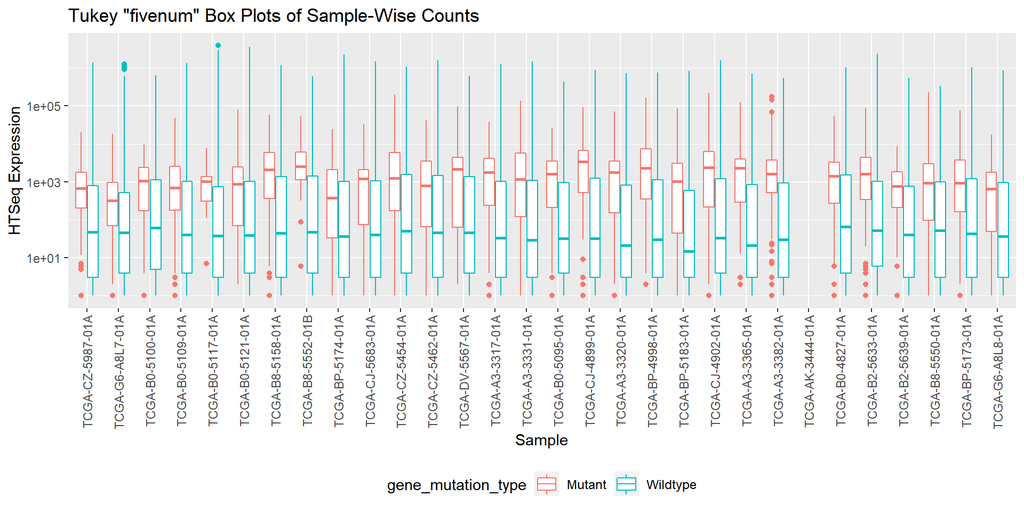

```r
sample_barcodes =
  counts_and_mutations %>%
  select(sample_barcode) %>%
  distinct() %>%
  pull()

counts_and_mutations %>%

  filter(sample_barcode %in% sample(sample_barcodes, 30)) %>%

  group_by(sample_barcode) %>%
    mutate(sample_median = median(HTSeq__Counts)) %>%
  ungroup() %>%
  # filter(gene_median > 100) %>%
  ggplot(aes(
    x = reorder(sample_barcode, sample_median),
    y=HTSeq__Counts,
    color=gene_mutation_type
  )) +
  # geom_violin() +
  geom_boxplot() +
  # geom_quasirandom(size = 0.1) +
  scale_y_log10() +

  ggtitle("Tukey \"fivenum\" Box Plots of Sample-Wise Counts") +

  theme(
    axis.text.x = element_text(angle = 90, vjust = 0.5, hjust=1),
    legend.position = "bottom",
    legend.title = element_text(size = 11),
    legend.text = element_text(size = 9)
  ) +

  xlab("Sample") +
  ylab("HTSeq Expression")
```

#### 1.4.1.2 FPKM Upper Quantile Normalized

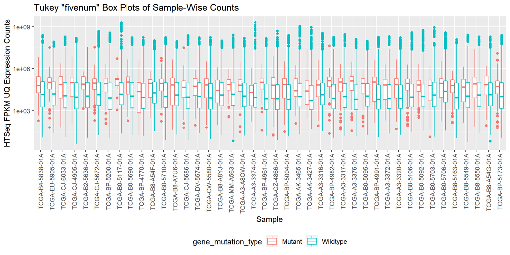

```r
sample_barcodes =
  counts_and_mutations %>%
  select(sample_barcode) %>%
  distinct() %>%
  pull()

counts_and_mutations %>%

  filter(sample_barcode %in% sample(sample_barcode, 50)) %>%

  group_by(sample_barcode) %>%
    mutate(sample_median = median(HTSeq__FPKM_UQ)) %>%
  ungroup() %>%
  # filter(gene_median > 100) %>%
  ggplot(aes(
    x = reorder(sample_barcode, sample_median),
    y=HTSeq__FPKM_UQ,
    color=gene_mutation_type
  )) +
  # geom_violin() +
  geom_boxplot() +
  # geom_quasirandom(size = 0.1) +
  scale_y_log10() +

  ggtitle("Tukey \"fivenum\" Box Plots of Sample-Wise Counts") +

  theme(
    axis.text.x = element_text(angle = 90, vjust = 0.5, hjust=1),
    legend.position = "bottom",
    legend.title = element_text(size = 11),
    legend.text = element_text(size = 9)
  ) +

  xlab("Sample") +
  ylab("HTSeq FPKM UQ Expression Counts")
```

### 1.4.2 Gene-Wise Counts

#### 1.4.2.1 Raw

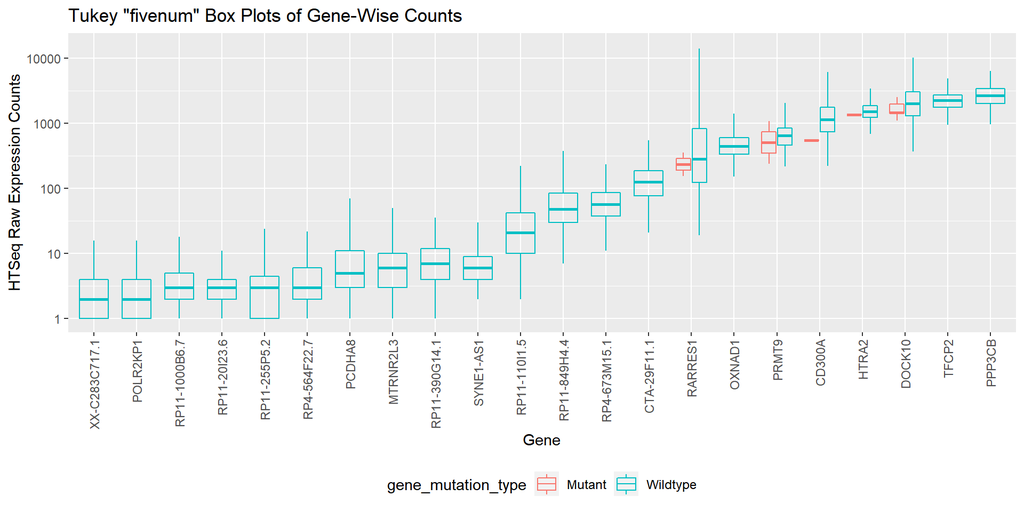

```r
gene_symbols =
  counts_and_mutations %>%
  select(gene_symbol) %>%
  distinct() %>%
  pull()

counts_and_mutations %>%
  filter(gene_symbol %in% sample(gene_symbols, 50)) %>%

  group_by(gene_symbol) %>%

    mutate(gene_median = median(HTSeq__Counts)) %>%
  ungroup() %>%

  filter(gene_median > 0) %>%

  ggplot(aes(
    x = reorder(gene_symbol, gene_median),
    y=HTSeq__Counts,
    color=gene_mutation_type
  )) +
  # geom_violin() +
  geom_boxplot(alpha = 0) +
  # geom_quasirandom() +
  scale_y_log10() +

  ggtitle("Tukey \"fivenum\" Box Plots of Gene-Wise Counts") +

  theme(
    axis.text.x = element_text(angle = 90, vjust = 0.5, hjust=1),
    legend.position = "bottom",
    legend.title = element_text(size = 11),
    legend.text = element_text(size = 9)
  ) +

  xlab("Gene") +
  ylab("HTSeq Raw Expression Counts")
```

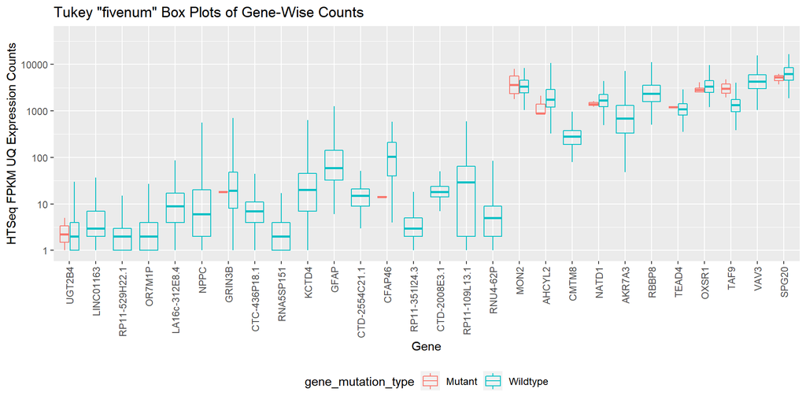

```r
gene_symbols =
  counts_and_mutations %>%
  select(gene_symbol) %>%
  distinct() %>%
  pull()

counts_and_mutations %>%
  filter(gene_symbol %in% sample(gene_symbols, 50)) %>%

  group_by(gene_symbol) %>%

    mutate(gene_median = median(HTSeq__FPKM_UQ)) %>%
  ungroup() %>%

  filter(gene_median > 0) %>%

  ggplot(aes(
    x = reorder(gene_symbol, gene_median),
    y=HTSeq__Counts,
    color=gene_mutation_type
  )) +
  # geom_violin() +
  geom_boxplot(alpha = 0) +
  # geom_quasirandom() +
  scale_y_log10() +

  ggtitle("Tukey \"fivenum\" Box Plots of Gene-Wise Counts") +

  theme(
    axis.text.x = element_text(angle = 90, vjust = 0.5, hjust=1),
    legend.position = "bottom",
    legend.title = element_text(size = 11),
    legend.text = element_text(size = 9)
  ) +

  xlab("Gene") +
  ylab("HTSeq FPKM UQ Expression Counts")
```

## 1.5 Descriptive Stats—Plots

### 1.5.1 Sample-Wise—Plots

#### 1.5.1.1 Calculate Descriptive Stats—Mutant vs. Wildtype

```r
sample_wise_descriptive_stats =
  counts_and_mutations %>%
  pivot_longer(
    cols = starts_with("HTSeq"),
    names_to = "counts_type",
    values_to = "counts"
  ) %>%
  group_by(sample_barcode, gene_mutation_type, counts_type) %>%
    summarize(
      Min = min(counts),
      Q1 = quantile(counts, 0.25, na.rm=T),
      Median = median(counts, na.rm=T),
      Mean = mean(counts, na.rm=T),
      SD = sd(counts, na.rm=T),
      Var = var(counts, na.rm=T),
      Q3 = quantile(counts, 0.75, na.rm=T),
      Max = max(counts),
      IQR = Q3 - Q1
    ) %>%
  arrange(Max) %>%
  tail(-1) %>%
  ungroup() %>%
  ungroup()
object.size(sample_wise_descriptive_stats)
```

```
270488 bytes
```

```r
gc()
```

```
            used   (Mb) gc trigger    (Mb)   max used    (Mb)
Ncells   2665554  142.4   21189148  1131.7   35720684  1907.7
Vcells 420387704 3207.4 1382472926 10547.5 1760424125 13431.0
```

```r
sample_wise_descriptive_stats %>%
  sample_n(20) %>%
  displayTable(caption = "Random Sample-Wise Descriptive Stats (N=20)")
```

| sample_barcode | gene_mutation_type | counts_type | Min | Q1 | Median | Mean | SD | Var | Q3 | Max | IQR |
| --- | --- | --- | --- | --- | --- | --- | --- | --- | --- | --- | --- |
| TCGA-B8-5552-01B | Wildtype | HTSeq__FPKM | 0 | 0 | 0.0176156351854 | 4.45166267620715 | 58.6241760847872 | 3436.79402162013 | 0.63697608468775 | 5693.83076153 | 0.63697608468775 |
| TCGA-BP-4986-01A | Mutant | HTSeq__FPKM_UQ | 0 | 20867.719386725 | 70302.2727716 | 206760.170997882 | 388977.423356542 | 151303435881.095 | 143097.91927625 | 2094824.72667 | 122230.199889525 |
| TCGA-A3-A6NJ-01A | Wildtype | HTSeq__Counts | 0 | 0 | 1 | 914.609868736861 | 7324.15495352117 | 53643245.7831887 | 68 | 696470 | 68 |
| TCGA-A3-3370-01A | Wildtype | HTSeq__FPKM | 0 | 0 | 0.0620407584237 | 4.88845255293224 | 94.1367170340244 | 8861.72149394399 | 0.916370483704 | 9971.1471339 | 0.916370483704 |
| TCGA-A3-A6NN-01A | Wildtype | HTSeq__FPKM_UQ | 0 | 0 | 594.094463396 | 102224.312772677 | 1679761.79251852 | 2821599679605.05 | 17360.2069337 | 190309906.164 | 17360.2069337 |
| TCGA-A3-3363-01A | Mutant | HTSeq__FPKM |  | 0.969265377741 | 4.08719671686 | 13.330447076909 | 29.788875544837 | 887.377106225786 | 9.122231534695 |  | 8.152966156954 |
| TCGA-B0-5115-01A | Mutant | HTSeq__FPKM_UQ | 0 | 11685.28912835 | 78946.52388315 | 166664.314932552 | 388000.192686759 | 150544149524.962 | 156201.08041575 | 2998925.17827 | 144515.7912874 |
| TCGA-B0-5088-01A | Wildtype | HTSeq__Counts | 0 | 0 | 2 | 1181.35587495032 | 17835.8701616146 | 318118264.421976 | 108 | 2422939 | 108 |
| TCGA-B4-5832-01A | Mutant | HTSeq__FPKM |  | 0 | 0.434034680442 | 5.61937798747466 | 11.9208255121677 | 142.106080891548 | 5.2998876424475 |  | 5.2998876424475 |
| TCGA-B0-5108-01A | Wildtype | HTSeq__FPKM | 0 | 0 | 0.0253482982207 | 4.97951339992019 | 84.9553567526683 | 7217.41264097314 | 0.691720324624 | 7455.09507881 | 0.691720324624 |

[output cut: 10 more lines]

#### 1.5.1.2 Median vs. IQR

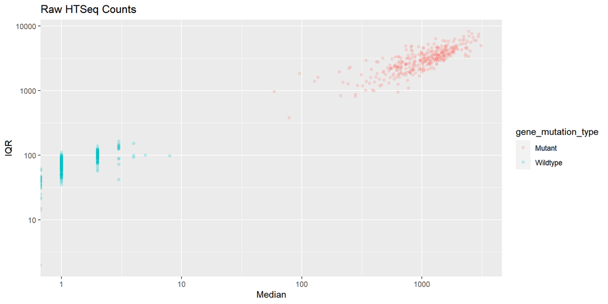

```r
sample_wise_descriptive_stats %>%
  filter(counts_type == "HTSeq__Counts") %>%
  ggplot(aes(x=Median, y=IQR, color=gene_mutation_type)) +
  geom_point(alpha = 0.2) +
  scale_x_log10() +
  scale_y_log10() +
  ggtitle("Raw HTSeq Counts")
```

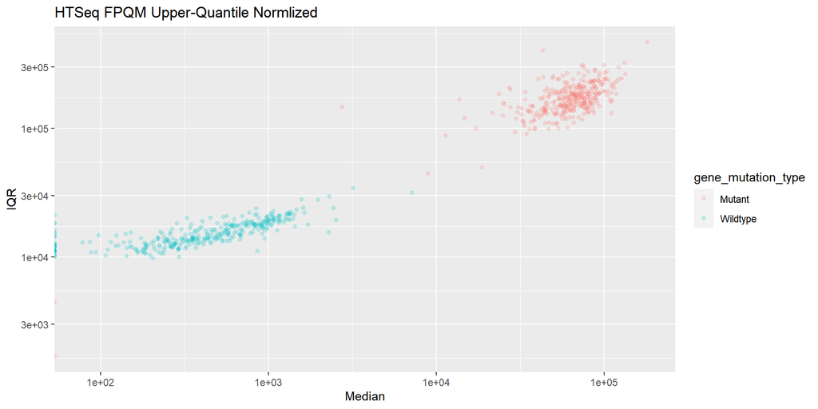

```r
sample_wise_descriptive_stats %>%
  filter(counts_type == "HTSeq__FPKM_UQ") %>%
  ggplot(aes(x=Median, y=IQR, color=gene_mutation_type)) +
  geom_point(alpha = 0.2) +
  scale_x_log10() +
  scale_y_log10() +
  ggtitle("HTSeq FPQM Upper-Quantile Normlized")
```

#### 1.5.1.3 Mean vs. Variance

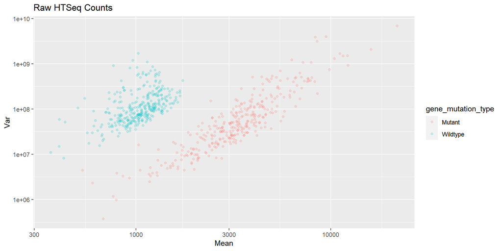

```r
sample_wise_descriptive_stats %>%
  filter(counts_type == "HTSeq__Counts") %>%
  ggplot(aes(x=Mean, y=Var, color=gene_mutation_type)) +
  geom_point(alpha = 0.2) +
  scale_x_log10() +
  scale_y_log10() +
  ggtitle("Raw HTSeq Counts")
```

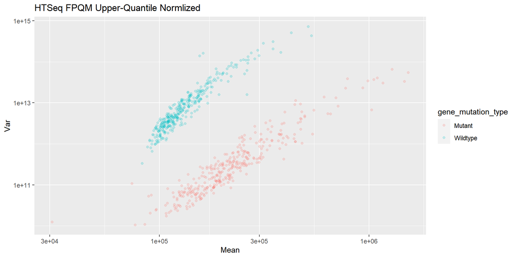

```r
sample_wise_descriptive_stats %>%
  filter(counts_type == "HTSeq__FPKM_UQ") %>%
  ggplot(aes(x=Mean, y=Var, color=gene_mutation_type)) +
  geom_point(alpha = 0.2) +
  scale_x_log10() +
  scale_y_log10() +
  ggtitle("HTSeq FPQM Upper-Quantile Normlized")
```

#### 1.5.1.4 Calculate Descriptive Stats—All Variant Classifications

**Raw Expression Counts Only***

```r
sample_wise_descriptive_stats_varclass =
  counts_and_mutations %>%
  pivot_longer(
    cols = starts_with("HTSeq"),
    names_to = "counts_type",
    values_to = "counts"
  ) %>%
  filter(counts_type == "HTSeq__Counts") %>%
  mutate(counts = counts + 1) %>%
  group_by(sample_barcode, variant_classification) %>%
    summarize(
      Min = min(counts),
      Q1 = quantile(counts, 0.25, na.rm=T),
      Median = median(counts, na.rm=T),
      Mean = mean(counts, na.rm=T),
      SD = sd(counts, na.rm=T),
      Var = var(counts, na.rm=T),
      Q3 = quantile(counts, 0.75, na.rm=T),
      Max = max(counts),
      IQR = Q3 - Q1
    ) %>%
  arrange(Max) %>%
  tail(-1) %>%
  ungroup() %>%
  ungroup()
```

#### 1.5.1.5 Median vs. IQR

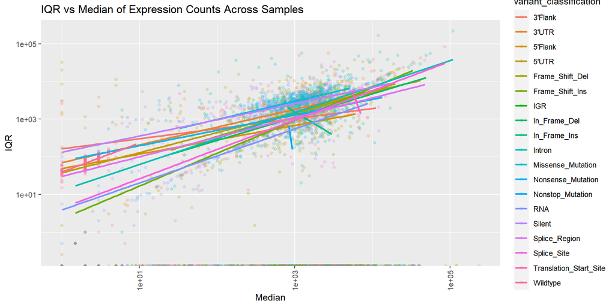

```r
sample_wise_descriptive_stats_varclass %>%
  ggplot(aes(x=Median, y=IQR, color=variant_classification)) +
  geom_point(alpha = 0.2) +
  scale_x_log10() +
  scale_y_log10() +
  geom_smooth(method=lm, formula=y~x, size=1, se=F) +
  ggtitle(
    "IQR vs Median of Expression Counts Across Samples"
  ) +

  theme(axis.text.x = element_text(angle = 90, vjust = 0.5, hjust=1))
```

```r
# rm(descriptive_stats_with_variant_class)
#
# gc()
```

#### 1.5.1.6 Mean vs. Var

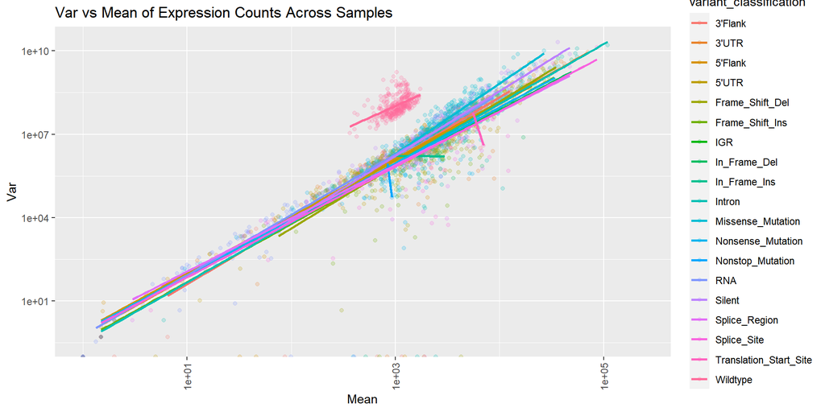

```r
sample_wise_descriptive_stats_varclass %>%
  ggplot(aes(x=Mean, y=Var, color=variant_classification)) +
  geom_point(alpha = 0.2) +
  scale_x_log10() +
  scale_y_log10() +
  geom_smooth(method=lm, formula=y~x, size=1, se=F) +
  ggtitle(
    "Var vs Mean of Expression Counts Across Samples"
  ) +

  theme(axis.text.x = element_text(angle = 90, vjust = 0.5, hjust=1))
```

```r
# rm(descriptive_stats_with_variant_class)
#
# gc()
```

### 1.5.2 Sample-Wise—Statistical Testing

We want to statistically test what seems to apparent in the plots

#### 1.5.2.1 Difference in Central Tendency

##### 1.5.2.1.1 Raw—Median

```r
raw =
  sample_wise_descriptive_stats %>%
  filter(counts_type == "HTSeq__Counts") %>%
  lm(log(Median+1) ~ gene_mutation_type, .)
summary(raw)
```

```
Call:
lm(formula = log(Median + 1) ~ gene_mutation_type, data = .)

Residuals:
    Min      1Q  Median      3Q     Max
-6.8500 -0.0736 -0.0736  0.3319  1.4305

Coefficients:
                           Estimate Std. Error t value Pr(>|t|)
(Intercept)                 6.85003    0.03382   202.6   <2e-16 ***
gene_mutation_typeWildtype -6.08328    0.04783  -127.2   <2e-16 ***
---
Signif. codes:  0 '***' 0.001 '**' 0.01 '*' 0.05 '.' 0.1 ' ' 1

Residual standard error: 0.6162 on 662 degrees of freedom
  (4 observations deleted due to missingness)
Multiple R-squared:  0.9607,    Adjusted R-squared:  0.9606
F-statistic: 1.618e+04 on 1 and 662 DF,  p-value: < 2.2e-16
```

##### 1.5.2.1.2 FPKM UQ—Mean

```r
fpkm_uq =
  sample_wise_descriptive_stats %>%
  filter(Mean>0 & !is.na(Mean)) %>%
  filter(counts_type == "HTSeq__FPKM_UQ") %>%
  lm(log(Mean) ~ gene_mutation_type, .)
summary(fpkm_uq)
```

```
Call:
lm(formula = log(Mean) ~ gene_mutation_type, data = .)

Residuals:
     Min       1Q   Median       3Q      Max
-1.97499 -0.24520 -0.06571  0.16023  1.93895

Coefficients:
                           Estimate Std. Error t value Pr(>|t|)
(Intercept)                 12.3094     0.0232  530.66   <2e-16 ***
gene_mutation_typeWildtype  -0.5033     0.0328  -15.34   <2e-16 ***
---
Signif. codes:  0 '***' 0.001 '**' 0.01 '*' 0.05 '.' 0.1 ' ' 1

Residual standard error: 0.4227 on 662 degrees of freedom
Multiple R-squared:  0.2623,    Adjusted R-squared:  0.2612
F-statistic: 235.4 on 1 and 662 DF,  p-value: < 2.2e-16
```

#### 1.5.2.2 Full Model

##### 1.5.2.2.1 Raw—Median

```r
raw =
  sample_wise_descriptive_stats %>%
  filter(counts_type == "HTSeq__Counts") %>%
  lm(log(IQR+1) ~ log(Median+1)*gene_mutation_type, .)
summary(raw)
```

```
Call:
lm(formula = log(IQR + 1) ~ log(Median + 1) * gene_mutation_type,
    data = .)

Residuals:
     Min       1Q   Median       3Q      Max
-1.91524 -0.14683  0.00887  0.15159  1.21293

Coefficients:
                                           Estimate Std. Error t value Pr(>|t|)
(Intercept)                                 3.01385    0.12277  24.550  < 2e-16
log(Median + 1)                             0.71990    0.01780  40.444  < 2e-16
gene_mutation_typeWildtype                  0.68604    0.12789   5.364 1.12e-07
log(Median + 1):gene_mutation_typeWildtype  0.03620    0.04639   0.780    0.436

(Intercept)                                ***
log(Median + 1)                            ***
gene_mutation_typeWildtype                 ***
log(Median + 1):gene_mutation_typeWildtype
---
Signif. codes:  0 '***' 0.001 '**' 0.01 '*' 0.05 '.' 0.1 ' ' 1

Residual standard error: 0.2606 on 660 degrees of freedom
  (4 observations deleted due to missingness)
Multiple R-squared:  0.9814,    Adjusted R-squared:  0.9813
F-statistic: 1.16e+04 on 3 and 660 DF,  p-value: < 2.2e-16
```

##### 1.5.2.2.2 FPKM UQ—Mean

```r
fpkm_uq =
  sample_wise_descriptive_stats %>%
  filter(counts_type == "HTSeq__FPKM_UQ") %>%
  lm(log(Var) ~ log(Mean)*gene_mutation_type, .)
summary(fpkm_uq)
```

```
Call:
lm(formula = log(Var) ~ log(Mean) * gene_mutation_type, data = .)

Residuals:
     Min       1Q   Median       3Q      Max
-1.99579 -0.35904  0.00042  0.30360  2.78202

Coefficients:
                                      Estimate Std. Error t value Pr(>|t|)
(Intercept)                          -10.67112    0.68422 -15.596  < 2e-16 ***
log(Mean)                              3.01158    0.05554  54.227  < 2e-16 ***
gene_mutation_typeWildtype            -7.56927    1.30702  -5.791 1.08e-08 ***
log(Mean):gene_mutation_typeWildtype   1.04634    0.10943   9.561  < 2e-16 ***
---
Signif. codes:  0 '***' 0.001 '**' 0.01 '*' 0.05 '.' 0.1 ' ' 1

Residual standard error: 0.5204 on 660 degrees of freedom
  (4 observations deleted due to missingness)
Multiple R-squared:  0.945, Adjusted R-squared:  0.9447
F-statistic:  3780 on 3 and 660 DF,  p-value: < 2.2e-16
```

```r
rm(rnaseq_counts)
rm(mutations)
gc()
```

```
            used   (Mb) gc trigger   (Mb)   max used    (Mb)
Ncells   2667053  142.5   13561056  724.3   35720684  1907.7
Vcells 253887868 1937.1 1105978341 8438.0 1760424125 13431.0
```

### 1.5.3 Gene-Wise—Plots

#### 1.5.3.1 Calculate Descriptive Stats—Mutant vs. Wildtype

```r
gene_wise_descriptive_stats =
  counts_and_mutations %>%
  pivot_longer(
    cols = starts_with("HTSeq"),
    names_to = "counts_type",
    values_to = "counts"
  ) %>%
  group_by(gene_symbol, gene_mutation_type, counts_type) %>%
    summarize(
      Min = min(counts),
      Q1 = quantile(counts, 0.25, na.rm=T),
      Median = median(counts, na.rm=T),
      Mean = mean(counts, na.rm=T),
      SD = sd(counts, na.rm=T),
      Var = var(counts, na.rm=T),
      Q3 = quantile(counts, 0.75, na.rm=T),
      Max = max(counts),
      IQR = Q3 - Q1
    ) %>%
  arrange(Max) %>%
  tail(-1) %>%
  ungroup()
gc()
```

```
            used   (Mb) gc trigger   (Mb)   max used    (Mb)
Ncells   2667128  142.5    8679076  463.6   35720684  1907.7
Vcells 257085286 1961.5 1274227848 9721.6 1760424125 13431.0
```

#### 1.5.3.2 Median vs. IQR

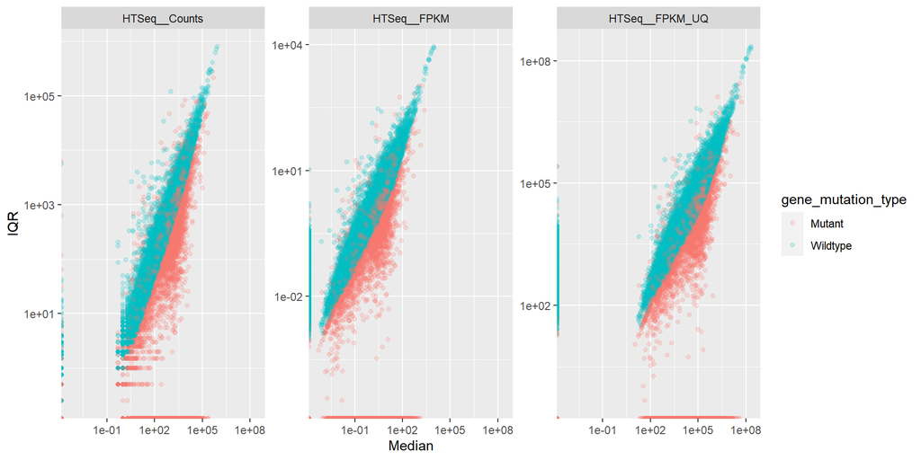

```r
gene_wise_descriptive_stats %>%
  ggplot(aes(x=Median, y=IQR, color=gene_mutation_type)) +
  geom_point(alpha = 0.2) +
  scale_x_log10() +
  scale_y_log10() +
  facet_wrap(
    ~counts_type,
    ncol=3,
    scales="free_y",
    strip.position = "top"
  )
```

#### 1.5.3.3 Mean vs. Variance

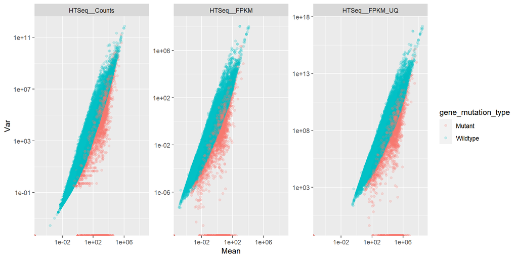

```r
gene_wise_descriptive_stats %>%
  ggplot(aes(x=Mean, y=Var, color=gene_mutation_type)) +
  geom_point(alpha = 0.2) +
  scale_x_log10() +
  scale_y_log10() +
  facet_wrap(
    ~counts_type,
    ncol=3,
    scales="free_y",
    strip.position = "top"
  )
```